# Capstone_task_2.2

```python
import numpy as np
import pandas as pd
import matplotlib.pyplot as plt
import seaborn as sns
```

```python
df = pd.read_csv("C:/Users/chittreddy/Documents/Car_sales_details_p3.csv") #importing data
df
```

|  | Sales_ID | name | year | selling_price | km_driven | State or Province | City | fuel | seller_type | transmission | owner | mileage | engine | max_power | seats |
| --- | --- | --- | --- | --- | --- | --- | --- | --- | --- | --- | --- | --- | --- | --- | --- |
| 0 | 1 | Maruti Swift Dzire VDI | 2014 | 450000 | 145500 | District of Columbia | Washington | Diesel | Individual | Manual | First Owner | 23.4 kmpl | 1248 CC | 74 bhp | 5 |
| 1 | 2 | Skoda Rapid 1.5 TDI Ambition | 2014 | 370000 | 120000 | New York | New York City | Diesel | Individual | Manual | Second Owner | 21.14 kmpl | 1498 CC | 103.52 bhp | 5 |
| 2 | 3 | Honda City 2017-2020 EXi | 2006 | 158000 | 140000 | Illinois | Chicago | Petrol | Individual | Manual | Third Owner | 17.7 kmpl | 1497 CC | 78 bhp | 5 |
| 3 | 4 | Hyundai i20 Sportz Diesel | 2010 | 225000 | 127000 | Illinois | Chicago | Diesel | Individual | Manual | First Owner | 23.0 kmpl | 1396 CC | 90 bhp | 5 |
| 4 | 5 | Maruti Swift VXI BSIII | 2007 | 130000 | 120000 | New York | New York City | Petrol | Individual | Manual | First Owner | 16.1 kmpl | 1298 CC | 88.2 bhp | 5 |
| ... | ... | ... | ... | ... | ... | ... | ... | ... | ... | ... | ... | ... | ... | ... | ... |
| 7901 | 8124 | Hyundai i20 Magna | 2013 | 320000 | 110000 | Texas | Plano | Petrol | Individual | Manual | First Owner | 18.5 kmpl | 1197 CC | 82.85 bhp | 5 |
| 7902 | 8125 | Hyundai Verna CRDi SX | 2007 | 135000 | 119000 | Texas | Port Arthur | Diesel | Individual | Manual | Fourth & Above Owner | 16.8 kmpl | 1493 CC | 110 bhp | 5 |
| 7903 | 8126 | Maruti Swift Dzire ZDi | 2009 | 382000 | 120000 | Texas | Port Arthur | Diesel | Individual | Manual | First Owner | 19.3 kmpl | 1248 CC | 73.9 bhp | 5 |
| 7904 | 8127 | Tata Indigo CR4 | 2013 | 290000 | 25000 | Massachusetts | Lunenburg | Diesel | Individual | Manual | First Owner | 23.57 kmpl | 1396 CC | 70 bhp | 5 |
| 7905 | 8128 | Tata Indigo CR4 | 2013 | 290000 | 25000 | Maine | Augusta | Diesel | Individual | Manual | First Owner | 23.57 kmpl | 1396 CC | 70 bhp | 5 |

7906 rows × 15 columns

```python
def remove_model_name(x): #function that splits the data based on space
    return x.split(" ")[0]
```

```python
df["name"]=df["name"].apply(remove_model_name) #applying only brand names
```

```python
df["mileage"]=df["mileage"].apply(remove_model_name)#Displaying only the number
```

```python
df["max_power"]=df["max_power"].apply(remove_model_name)#Displaying only the number
```

```python
df["engine"]=df["engine"].apply(remove_model_name)#Displaying only the number
```

```python
df.dtypes
```

```
Sales_ID              int64
name                 object
year                  int64
selling_price         int64
km_driven             int64
State or Province    object
City                 object
fuel                 object
seller_type          object
transmission         object
owner                object
mileage              object
engine               object
max_power            object
seats                 int64
dtype: object
```

```python
df["mileage"] = df['mileage'].astype(float)#converting the datatype to float
```

```python
df["engine"] = df['engine'].astype(float)#converting the datatype to float
```

```python
df["max_power"] = df['max_power'].astype(float)#converting the datatype to float
```

# 1. Univariate, Bi- Variate Analysis and Multi- Variate Analysis

# Univariate

```python
uni=df[df['name']=='Maruti']
uni.head()
```

|  | Sales_ID | name | year | selling_price | km_driven | State or Province | City | fuel | seller_type | transmission | owner | mileage | engine | max_power | seats |
| --- | --- | --- | --- | --- | --- | --- | --- | --- | --- | --- | --- | --- | --- | --- | --- |
| 0 | 1 | Maruti | 2014 | 450000 | 145500 | District of Columbia | Washington | Diesel | Individual | Manual | First Owner | 23.4 | 1248.0 | 74.0 | 5 |
| 4 | 5 | Maruti | 2007 | 130000 | 120000 | New York | New York City | Petrol | Individual | Manual | First Owner | 16.1 | 1298.0 | 88.2 | 5 |
| 6 | 7 | Maruti | 2007 | 96000 | 175000 | California | Los Angeles | LPG | Individual | Manual | First Owner | 17.3 | 1061.0 | 57.5 | 5 |
| 7 | 8 | Maruti | 2001 | 45000 | 5000 | California | Los Angeles | Petrol | Individual | Manual | Second Owner | 16.1 | 796.0 | 37.0 | 4 |
| 11 | 12 | Maruti | 2005 | 92000 | 100000 | Texas | Houston | Petrol | Individual | Manual | Second Owner | 17.3 | 993.0 | 60.0 | 5 |

```python
np.mean(uni['selling_price']) #mean
```

```
409011.1411068864
```

Average selling price of maruti cars is 409011.14

```python
np.median(uni['selling_price']) #median
```

```
375000.0
```

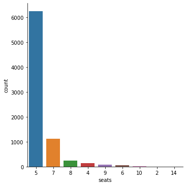

```python
a=sns.catplot(x="seats",data=df,kind="count",order=df["seats"].value_counts().index)#count_plot
plt.show()
```

So cars with 5 seats are mostly present in the analysis

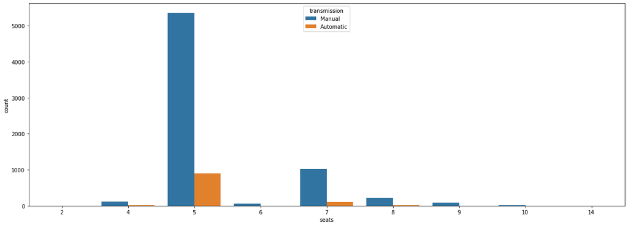

```python
plt.figure(figsize=(20,7))
sns.countplot(df["seats"],hue=df["transmission"])
```

# Bivariate

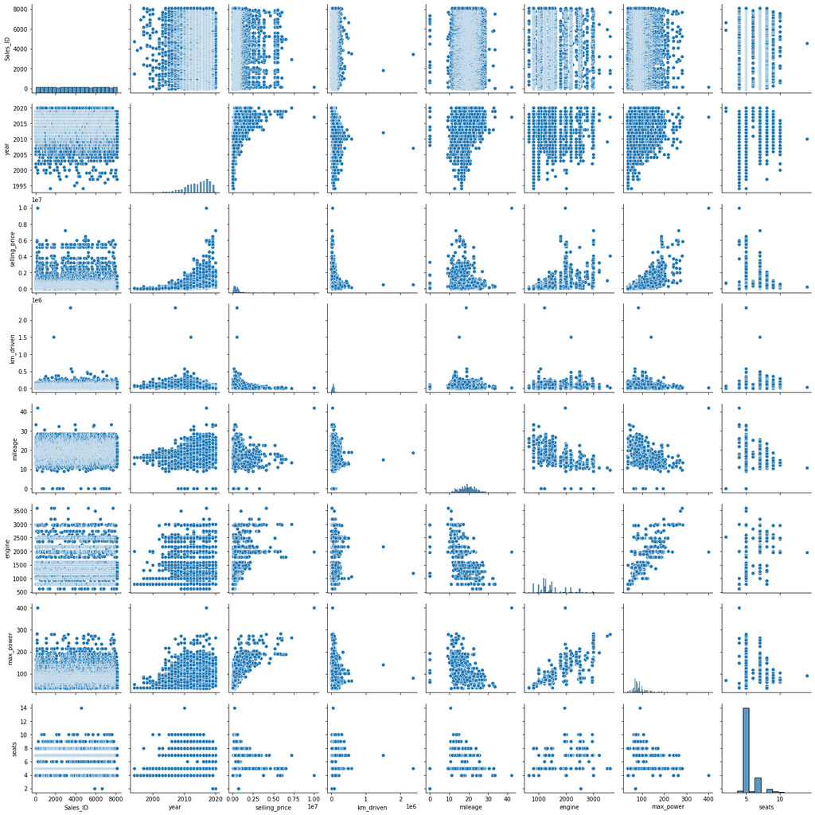

```python
sns.pairplot(df);
```

# Multivariate

```python
df.corr() #correlation
```

|  | Sales_ID | year | selling_price | km_driven | mileage | engine | max_power | seats |
| --- | --- | --- | --- | --- | --- | --- | --- | --- |
| Sales_ID | 1.000000 | -0.001304 | -0.012125 | 0.009556 | 0.028627 | -0.011279 | -0.003717 | -0.014154 |
| year | -0.001304 | 1.000000 | 0.412302 | -0.428548 | 0.328544 | 0.018263 | 0.226598 | -0.007923 |
| selling_price | -0.012125 | 0.412302 | 1.000000 | -0.222158 | -0.126280 | 0.455682 | 0.749674 | 0.041617 |
| km_driven | 0.009556 | -0.428548 | -0.222158 | 1.000000 | -0.172980 | 0.206031 | -0.038159 | 0.227259 |
| mileage | 0.028627 | 0.328544 | -0.126280 | -0.172980 | 1.000000 | -0.576408 | -0.374621 | -0.451700 |
| engine | -0.011279 | 0.018263 | 0.455682 | 0.206031 | -0.576408 | 1.000000 | 0.703975 | 0.611103 |
| max_power | -0.003717 | 0.226598 | 0.749674 | -0.038159 | -0.374621 | 0.703975 | 1.000000 | 0.191999 |
| seats | -0.014154 | -0.007923 | 0.041617 | 0.227259 | -0.451700 | 0.611103 | 0.191999 | 1.000000 |

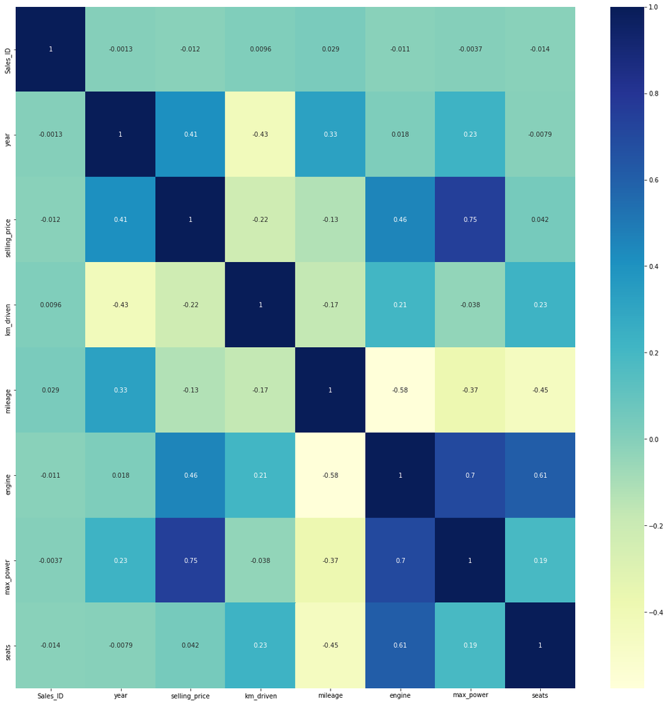

```python
plt.figure(figsize=(20,20))
sns.heatmap(df.corr(), cmap="YlGnBu", annot=True)
plt.show()
```

As max power corelation coefficient is greater that 0.7 wrt selling price, max power is highly correlated with selling price

# 2. Missing values identification and treatment

```python
df.isnull().sum()
```

```
Sales_ID             0
name                 0
year                 0
selling_price        0
km_driven            0
State or Province    0
City                 0
fuel                 0
seller_type          0
transmission         0
owner                0
mileage              0
engine               0
max_power            0
seats                0
dtype: int64
```

The data have no missing values

# 3. Outlier analysis and treatment

# Boxplot

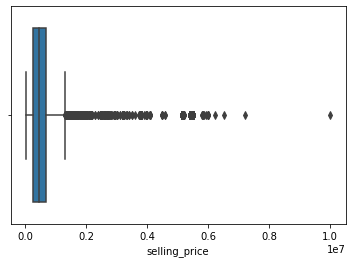

```python
sns.boxplot(x=df["selling_price"])
```

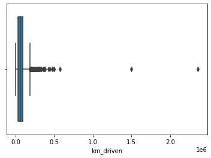

```python
sns.boxplot(x=df["km_driven"])
```

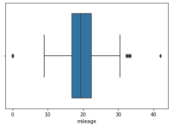

```python
sns.boxplot(x=df["mileage"])
```

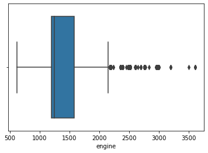

```python
sns.boxplot(x=df["engine"])
```

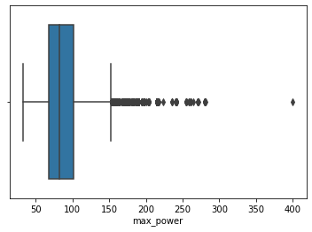

```python
sns.boxplot(x=df["max_power"])
```

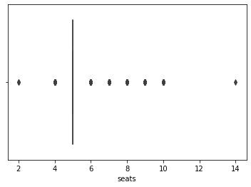

```python
sns.boxplot(x=df["seats"])
```

A point beyond an inner fence on either side is considered a mild outlier. A point beyond an outer fence is considered an extreme outlier

# Treatment

###### 1)Selling price

```python
Q1 = df.selling_price.quantile(0.25)
Q3 = df.selling_price.quantile(0.75)
Q1, Q3
IQR = Q3 - Q1
IQR

lower_limit = Q1 - 1.5*IQR
upper_limit = Q3 + 1.5*IQR
lower_limit, upper_limit

df = df[(df.selling_price>lower_limit)&(df.selling_price<upper_limit)]
df.shape
```

```
(7308, 15)
```

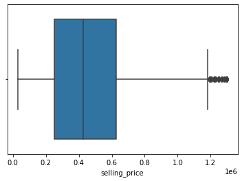

```python
sns.boxplot(x=df["selling_price"])
```

###### 2)Km_driven

```python
Q1 = df.km_driven.quantile(0.25)
Q3 = df.km_driven.quantile(0.75)
Q1, Q3
IQR = Q3 - Q1
IQR

lower_limit = Q1 - 1.5*IQR
upper_limit = Q3 + 1.5*IQR
lower_limit, upper_limit

df = df[(df.km_driven>lower_limit)&(df.km_driven<upper_limit)]
df.shape
```

```
(7151, 15)
```

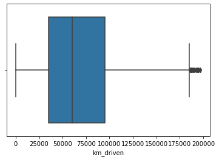

```python
sns.boxplot(x=df["km_driven"])
```

###### 3)Mileage

```python
Q1 = df.mileage.quantile(0.25)
Q3 = df.mileage.quantile(0.75)
Q1, Q3
IQR = Q3 - Q1
IQR

lower_limit = Q1 - 1.5*IQR
upper_limit = Q3 + 1.5*IQR
lower_limit, upper_limit

df = df[(df.mileage>lower_limit)&(df.mileage<upper_limit)]
df.shape
```

```
(7132, 15)
```

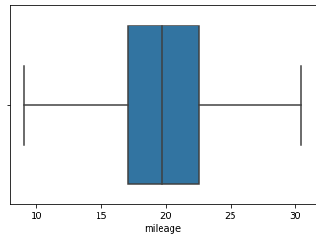

```python
sns.boxplot(x=df["mileage"])
```

```python
Q1 = df.engine.quantile(0.25)
Q3 = df.engine.quantile(0.75)
Q1, Q3
IQR = Q3 - Q1
IQR

lower_limit = Q1 - 1.5*IQR
upper_limit = Q3 + 1.5*IQR
lower_limit, upper_limit

df = df[(df.engine>lower_limit)&(df.engine<upper_limit)]
df.shape
```

```
(6155, 15)
```

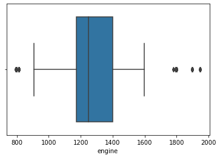

```python
sns.boxplot(x=df["engine"])
```

###### 5) Max Power

```python
Q1 = df.max_power.quantile(0.25)
Q3 = df.max_power.quantile(0.75)
Q1, Q3
IQR = Q3 - Q1
IQR

lower_limit = Q1 - 1.5*IQR
upper_limit = Q3 + 1.5*IQR
lower_limit, upper_limit

df = df[(df.max_power>lower_limit)&(df.max_power<upper_limit)]
df.shape
```

```
(5877, 15)
```

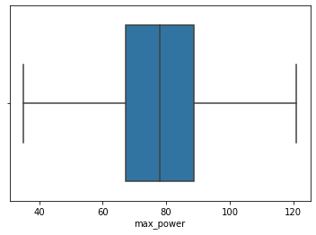

```python
sns.boxplot(x=df["max_power"])
```

# 4. Data scaling using min-max and/or Z-score normalisation

```python
df.shape
```

```
(5877, 15)
```

```python
df.describe()
```

|  | Sales_ID | year | selling_price | km_driven | mileage | engine | max_power | seats |
| --- | --- | --- | --- | --- | --- | --- | --- | --- |
| count | 5877.000000 | 5877.000000 | 5.877000e+03 | 5877.000000 | 5877.000000 | 5877.000000 | 5877.000000 | 5877.000000 |
| mean | 4084.273949 | 2013.974307 | 4.265508e+05 | 63140.528671 | 20.705966 | 1221.285180 | 77.983692 | 5.129828 |
| std | 2348.182057 | 3.927073 | 2.326810e+05 | 38563.740154 | 3.277681 | 214.960261 | 16.708651 | 0.570124 |
| min | 1.000000 | 1994.000000 | 2.999900e+04 | 1.000000 | 10.710000 | 793.000000 | 35.000000 | 4.000000 |
| 25% | 2059.000000 | 2012.000000 | 2.400000e+05 | 32000.000000 | 18.500000 | 1120.000000 | 67.100000 | 5.000000 |
| 50% | 4064.000000 | 2015.000000 | 4.000000e+05 | 60000.000000 | 20.500000 | 1199.000000 | 78.000000 | 5.000000 |
| 75% | 6126.000000 | 2017.000000 | 6.000000e+05 | 90000.000000 | 23.000000 | 1396.000000 | 88.700000 | 5.000000 |
| max | 8128.000000 | 2020.000000 | 1.300000e+06 | 195000.000000 | 30.460000 | 1948.000000 | 121.000000 | 14.000000 |

Right now the data is not in same scale

```python
Res= df[['Sales_ID','year','selling_price','km_driven','mileage','engine','max_power','seats']]
Res.head()
```

|  | Sales_ID | year | selling_price | km_driven | mileage | engine | max_power | seats |
| --- | --- | --- | --- | --- | --- | --- | --- | --- |
| 0 | 1 | 2014 | 450000 | 145500 | 23.40 | 1248.0 | 74.00 | 5 |
| 1 | 2 | 2014 | 370000 | 120000 | 21.14 | 1498.0 | 103.52 | 5 |
| 2 | 3 | 2006 | 158000 | 140000 | 17.70 | 1497.0 | 78.00 | 5 |
| 3 | 4 | 2010 | 225000 | 127000 | 23.00 | 1396.0 | 90.00 | 5 |
| 4 | 5 | 2007 | 130000 | 120000 | 16.10 | 1298.0 | 88.20 | 5 |

```python
from sklearn.preprocessing import MinMaxScaler
scaler = MinMaxScaler()
# fit and transform the data
df_norm = pd.DataFrame(scaler.fit_transform(Res), columns=Res.columns)
df_norm
```

|  | Sales_ID | year | selling_price | km_driven | mileage | engine | max_power | seats |
| --- | --- | --- | --- | --- | --- | --- | --- | --- |
| 0 | 0.000000 | 0.769231 | 0.330709 | 0.746153 | 0.642532 | 0.393939 | 0.453488 | 0.1 |
| 1 | 0.000123 | 0.769231 | 0.267717 | 0.615383 | 0.528101 | 0.610390 | 0.796744 | 0.1 |
| 2 | 0.000246 | 0.461538 | 0.100788 | 0.717947 | 0.353924 | 0.609524 | 0.500000 | 0.1 |
| 3 | 0.000369 | 0.615385 | 0.153544 | 0.651280 | 0.622278 | 0.522078 | 0.639535 | 0.1 |
| 4 | 0.000492 | 0.500000 | 0.078741 | 0.615383 | 0.272911 | 0.437229 | 0.618605 | 0.1 |
| ... | ... | ... | ... | ... | ... | ... | ... | ... |
| 5872 | 0.999508 | 0.730769 | 0.228347 | 0.564100 | 0.394430 | 0.349784 | 0.556395 | 0.1 |
| 5873 | 0.999631 | 0.500000 | 0.082678 | 0.610254 | 0.308354 | 0.606061 | 0.872093 | 0.1 |
| 5874 | 0.999754 | 0.576923 | 0.277166 | 0.615383 | 0.434937 | 0.393939 | 0.452326 | 0.1 |
| 5875 | 0.999877 | 0.730769 | 0.204725 | 0.128201 | 0.651139 | 0.522078 | 0.406977 | 0.1 |
| 5876 | 1.000000 | 0.730769 | 0.204725 | 0.128201 | 0.651139 | 0.522078 | 0.406977 | 0.1 |

5877 rows × 8 columns

Here we can see all the columns have values between 0 and 1 so we have the values on same scale

## Z score normalization

```python
Res.head()
```

|  | Sales_ID | year | selling_price | km_driven | mileage | engine | max_power | seats |
| --- | --- | --- | --- | --- | --- | --- | --- | --- |
| 0 | 1 | 2014 | 450000 | 145500 | 23.40 | 1248.0 | 74.00 | 5 |
| 1 | 2 | 2014 | 370000 | 120000 | 21.14 | 1498.0 | 103.52 | 5 |
| 2 | 3 | 2006 | 158000 | 140000 | 17.70 | 1497.0 | 78.00 | 5 |
| 3 | 4 | 2010 | 225000 | 127000 | 23.00 | 1396.0 | 90.00 | 5 |
| 4 | 5 | 2007 | 130000 | 120000 | 16.10 | 1298.0 | 88.20 | 5 |

```python
from sklearn.preprocessing import StandardScaler

# create a scaler object
std_scaler = StandardScaler()

df_std = pd.DataFrame(std_scaler.fit_transform(Res), columns=Res.columns)
df_std
```

|  | Sales_ID | year | selling_price | km_driven | mileage | engine | max_power | seats |
| --- | --- | --- | --- | --- | --- | --- | --- | --- |
| 0 | -1.739057 | 0.006543 | 0.100787 | 2.135853 | 0.822003 | 0.124289 | -0.238441 | -0.227739 |
| 1 | -1.738631 | 0.006543 | -0.243061 | 1.474554 | 0.132432 | 1.287393 | 1.528459 | -0.227739 |
| 2 | -1.738205 | -2.030771 | -1.154257 | 1.993220 | -0.917179 | 1.282741 | 0.000976 | -0.227739 |
| 3 | -1.737779 | -1.012114 | -0.866285 | 1.656087 | 0.699955 | 0.812846 | 0.719228 | -0.227739 |
| 4 | -1.737353 | -1.776106 | -1.274604 | 1.474554 | -1.405371 | 0.356909 | 0.611490 | -0.227739 |
| ... | ... | ... | ... | ... | ... | ... | ... | ... |
| 5872 | 1.720510 | -0.248121 | -0.457966 | 1.215221 | -0.673084 | -0.112985 | 0.291270 | -0.227739 |
| 5873 | 1.720936 | -1.776106 | -1.253113 | 1.448620 | -1.191787 | 1.264131 | 1.916315 | -0.227739 |
| 5874 | 1.721361 | -1.266778 | -0.191484 | 1.474554 | -0.428988 | 0.124289 | -0.244427 | -0.227739 |
| 5875 | 1.721787 | -0.248121 | -0.586909 | -0.989110 | 0.873873 | 0.812846 | -0.477859 | -0.227739 |
| 5876 | 1.722213 | -0.248121 | -0.586909 | -0.989110 | 0.873873 | 0.812846 | -0.477859 | -0.227739 |

5877 rows × 8 columns

# 5. Data transformation (min max scaling for transformed data)

```python
y=df["selling_price"] #target column
```

```python
X=df.drop("selling_price",axis="columns")
```

```python
X=X.drop("Sales_ID",axis="columns") #feature columns
```

```python
X.dtypes
```

```
name                  object
year                   int64
km_driven              int64
State or Province     object
City                  object
fuel                  object
seller_type           object
transmission          object
owner                 object
mileage              float64
engine               float64
max_power            float64
seats                  int64
dtype: object
```

```python
X=pd.get_dummies(X,columns=["City"],drop_first=True) #coverting the categorical type data into numerical data
```

```python
X=pd.get_dummies(X,columns=["State or Province"],drop_first=True)
```

```python
X=pd.get_dummies(X,columns=["fuel"],drop_first=True)
```

```python
X=pd.get_dummies(X,columns=["transmission"],drop_first=True)
```

```python
X=pd.get_dummies(X,columns=["owner"],drop_first=True)
```

```python
X=pd.get_dummies(X,columns=["name"],drop_first=True)
```

```python
X=pd.get_dummies(X,columns=["seller_type"],drop_first=True)
```

```python
X=pd.get_dummies(X,columns=["seats"],drop_first=True)
```

```python
X=pd.get_dummies(X,columns=["year"],drop_first=True)
```

```python
X.dtypes
```

```
km_driven       int64
mileage       float64
engine        float64
max_power     float64
City_Acton      uint8
               ...
year_2016       uint8
year_2017       uint8
year_2018       uint8
year_2019       uint8
year_2020       uint8
Length: 1358, dtype: object
```

```python
from sklearn.model_selection import train_test_split #splitting data into training and testing
```

```python
X_train,X_test,y_train,y_test=train_test_split(X,y,test_size=0.2,random_state=4)
```

```python
X.describe()
```

|  | km_driven | mileage | engine | max_power | City_Acton | City_Addison | City_Adrian | City_Aiken | City_Alamogordo | City_Albany | ... | year_2011 | year_2012 | year_2013 | year_2014 | year_2015 | year_2016 | year_2017 | year_2018 | year_2019 | year_2020 |
| --- | --- | --- | --- | --- | --- | --- | --- | --- | --- | --- | --- | --- | --- | --- | --- | --- | --- | --- | --- | --- | --- |
| count | 5877.000000 | 5877.000000 | 5877.000000 | 5877.000000 | 5877.000000 | 5877.000000 | 5877.000000 | 5877.000000 | 5877.000000 | 5877.000000 | ... | 5877.000000 | 5877.000000 | 5877.000000 | 5877.000000 | 5877.000000 | 5877.000000 | 5877.000000 | 5877.000000 | 5877.000000 | 5877.000000 |
| mean | 63140.528671 | 20.705966 | 1221.285180 | 77.983692 | 0.000170 | 0.000170 | 0.000170 | 0.000851 | 0.000681 | 0.001191 | ... | 0.066531 | 0.077761 | 0.079803 | 0.075549 | 0.096308 | 0.112813 | 0.134252 | 0.108559 | 0.065850 | 0.009699 |
| std | 38563.740154 | 3.277681 | 214.960261 | 16.708651 | 0.013044 | 0.013044 | 0.013044 | 0.029158 | 0.026082 | 0.034494 | ... | 0.249228 | 0.267818 | 0.271010 | 0.264297 | 0.295038 | 0.316391 | 0.340952 | 0.311111 | 0.248041 | 0.098012 |
| min | 1.000000 | 10.710000 | 793.000000 | 35.000000 | 0.000000 | 0.000000 | 0.000000 | 0.000000 | 0.000000 | 0.000000 | ... | 0.000000 | 0.000000 | 0.000000 | 0.000000 | 0.000000 | 0.000000 | 0.000000 | 0.000000 | 0.000000 | 0.000000 |
| 25% | 32000.000000 | 18.500000 | 1120.000000 | 67.100000 | 0.000000 | 0.000000 | 0.000000 | 0.000000 | 0.000000 | 0.000000 | ... | 0.000000 | 0.000000 | 0.000000 | 0.000000 | 0.000000 | 0.000000 | 0.000000 | 0.000000 | 0.000000 | 0.000000 |
| 50% | 60000.000000 | 20.500000 | 1199.000000 | 78.000000 | 0.000000 | 0.000000 | 0.000000 | 0.000000 | 0.000000 | 0.000000 | ... | 0.000000 | 0.000000 | 0.000000 | 0.000000 | 0.000000 | 0.000000 | 0.000000 | 0.000000 | 0.000000 | 0.000000 |
| 75% | 90000.000000 | 23.000000 | 1396.000000 | 88.700000 | 0.000000 | 0.000000 | 0.000000 | 0.000000 | 0.000000 | 0.000000 | ... | 0.000000 | 0.000000 | 0.000000 | 0.000000 | 0.000000 | 0.000000 | 0.000000 | 0.000000 | 0.000000 | 0.000000 |
| max | 195000.000000 | 30.460000 | 1948.000000 | 121.000000 | 1.000000 | 1.000000 | 1.000000 | 1.000000 | 1.000000 | 1.000000 | ... | 1.000000 | 1.000000 | 1.000000 | 1.000000 | 1.000000 | 1.000000 | 1.000000 | 1.000000 | 1.000000 | 1.000000 |

8 rows × 1358 columns

```python
from sklearn.preprocessing import MinMaxScaler #sacling of transformed data
```

```python
scaler=MinMaxScaler()
```

```python
X_train=scaler.fit_transform(X_train)
```

```python
X_test=scaler.transform(X_test)
```

```python
X_train1=pd.DataFrame(X_train,columns=X.columns)
```

```python
X_test1=pd.DataFrame(X_test,columns=X.columns)
```

```python
X_train1.describe()
```

|  | km_driven | mileage | engine | max_power | City_Acton | City_Addison | City_Adrian | City_Aiken | City_Alamogordo | City_Albany | ... | year_2011 | year_2012 | year_2013 | year_2014 | year_2015 | year_2016 | year_2017 | year_2018 | year_2019 | year_2020 |
| --- | --- | --- | --- | --- | --- | --- | --- | --- | --- | --- | --- | --- | --- | --- | --- | --- | --- | --- | --- | --- | --- |
| count | 4701.000000 | 4701.000000 | 4701.000000 | 4701.000000 | 4701.000000 | 4701.000000 | 4701.000000 | 4701.000000 | 4701.000000 | 4701.000000 | ... | 4701.000000 | 4701.000000 | 4701.000000 | 4701.000000 | 4701.000000 | 4701.000000 | 4701.000000 | 4701.000000 | 4701.000000 | 4701.000000 |
| mean | 0.323431 | 0.508300 | 0.370113 | 0.498380 | 0.000213 | 0.000213 | 0.000213 | 0.001064 | 0.000638 | 0.001276 | ... | 0.065731 | 0.076792 | 0.077218 | 0.075090 | 0.097213 | 0.113593 | 0.135716 | 0.109551 | 0.065731 | 0.009360 |
| std | 0.196396 | 0.165259 | 0.186271 | 0.194271 | 0.014585 | 0.014585 | 0.014585 | 0.032599 | 0.025256 | 0.035707 | ... | 0.247837 | 0.266290 | 0.266965 | 0.263565 | 0.296280 | 0.317350 | 0.342523 | 0.312363 | 0.247837 | 0.096302 |
| min | 0.000000 | 0.000000 | 0.000000 | 0.000000 | 0.000000 | 0.000000 | 0.000000 | 0.000000 | 0.000000 | 0.000000 | ... | 0.000000 | 0.000000 | 0.000000 | 0.000000 | 0.000000 | 0.000000 | 0.000000 | 0.000000 | 0.000000 | 0.000000 |
| 25% | 0.169227 | 0.394430 | 0.283117 | 0.373256 | 0.000000 | 0.000000 | 0.000000 | 0.000000 | 0.000000 | 0.000000 | ... | 0.000000 | 0.000000 | 0.000000 | 0.000000 | 0.000000 | 0.000000 | 0.000000 | 0.000000 | 0.000000 | 0.000000 |
| 50% | 0.307689 | 0.496203 | 0.351515 | 0.488372 | 0.000000 | 0.000000 | 0.000000 | 0.000000 | 0.000000 | 0.000000 | ... | 0.000000 | 0.000000 | 0.000000 | 0.000000 | 0.000000 | 0.000000 | 0.000000 | 0.000000 | 0.000000 | 0.000000 |
| 75% | 0.461536 | 0.622278 | 0.522078 | 0.624419 | 0.000000 | 0.000000 | 0.000000 | 0.000000 | 0.000000 | 0.000000 | ... | 0.000000 | 0.000000 | 0.000000 | 0.000000 | 0.000000 | 0.000000 | 0.000000 | 0.000000 | 0.000000 | 0.000000 |
| max | 1.000000 | 1.000000 | 1.000000 | 1.000000 | 1.000000 | 1.000000 | 1.000000 | 1.000000 | 1.000000 | 1.000000 | ... | 1.000000 | 1.000000 | 1.000000 | 1.000000 | 1.000000 | 1.000000 | 1.000000 | 1.000000 | 1.000000 | 1.000000 |

8 rows × 1358 columns

```python
X_test1.describe()
```

|  | km_driven | mileage | engine | max_power | City_Acton | City_Addison | City_Adrian | City_Aiken | City_Alamogordo | City_Albany | ... | year_2011 | year_2012 | year_2013 | year_2014 | year_2015 | year_2016 | year_2017 | year_2018 | year_2019 | year_2020 |
| --- | --- | --- | --- | --- | --- | --- | --- | --- | --- | --- | --- | --- | --- | --- | --- | --- | --- | --- | --- | --- | --- |
| count | 1176.000000 | 1176.000000 | 1176.000000 | 1176.000000 | 1176.0 | 1176.0 | 1176.0 | 1176.0 | 1176.000000 | 1176.000000 | ... | 1176.000000 | 1176.000000 | 1176.000000 | 1176.000000 | 1176.000000 | 1176.000000 | 1176.000000 | 1176.000000 | 1176.000000 | 1176.000000 |
| mean | 0.325247 | 0.497430 | 0.373594 | 0.505528 | 0.0 | 0.0 | 0.0 | 0.0 | 0.000850 | 0.000850 | ... | 0.069728 | 0.081633 | 0.090136 | 0.077381 | 0.092687 | 0.109694 | 0.128401 | 0.104592 | 0.066327 | 0.011054 |
| std | 0.203218 | 0.168516 | 0.185533 | 0.194325 | 0.0 | 0.0 | 0.0 | 0.0 | 0.029161 | 0.029161 | ... | 0.254796 | 0.273921 | 0.286498 | 0.267309 | 0.290117 | 0.312641 | 0.334678 | 0.306157 | 0.248958 | 0.104602 |
| min | 0.005123 | 0.059241 | 0.002597 | 0.000000 | 0.0 | 0.0 | 0.0 | 0.0 | 0.000000 | 0.000000 | ... | 0.000000 | 0.000000 | 0.000000 | 0.000000 | 0.000000 | 0.000000 | 0.000000 | 0.000000 | 0.000000 | 0.000000 |
| 25% | 0.157688 | 0.379241 | 0.340260 | 0.381105 | 0.0 | 0.0 | 0.0 | 0.0 | 0.000000 | 0.000000 | ... | 0.000000 | 0.000000 | 0.000000 | 0.000000 | 0.000000 | 0.000000 | 0.000000 | 0.000000 | 0.000000 | 0.000000 |
| 50% | 0.307689 | 0.485570 | 0.351515 | 0.523256 | 0.0 | 0.0 | 0.0 | 0.0 | 0.000000 | 0.000000 | ... | 0.000000 | 0.000000 | 0.000000 | 0.000000 | 0.000000 | 0.000000 | 0.000000 | 0.000000 | 0.000000 | 0.000000 |
| 75% | 0.461536 | 0.622278 | 0.522078 | 0.624419 | 0.0 | 0.0 | 0.0 | 0.0 | 0.000000 | 0.000000 | ... | 0.000000 | 0.000000 | 0.000000 | 0.000000 | 0.000000 | 0.000000 | 0.000000 | 0.000000 | 0.000000 | 0.000000 |
| max | 1.000000 | 1.000000 | 1.000000 | 1.000000 | 0.0 | 0.0 | 0.0 | 0.0 | 1.000000 | 1.000000 | ... | 1.000000 | 1.000000 | 1.000000 | 1.000000 | 1.000000 | 1.000000 | 1.000000 | 1.000000 | 1.000000 | 1.000000 |

8 rows × 1358 columns

# 6) Feature Engineering

```python
from sklearn.feature_selection import RFE
```

```python
from sklearn.linear_model import LinearRegression
```

```python
model=LinearRegression()
```

```python
feature_selection=RFE(model,20) #selecting 20 columns using RFE model
```

```python
feature_selection.fit(X_train,y_train)
```

```
RFE(estimator=LinearRegression(), n_features_to_select=20)
```

```python
TopColumns=X.columns[feature_selection.support_]
```

```python
X_train.shape
```

```
(4701, 1358)
```

```python
X_test.shape
```

```
(1176, 1358)
```

```python
X_train=pd.DataFrame(X_train,columns=X.columns)
```

```python
X_test=pd.DataFrame(X_test,columns=X.columns)
```

```python
X_train
```

|  | km_driven | mileage | engine | max_power | City_Acton | City_Addison | City_Adrian | City_Aiken | City_Alamogordo | City_Albany | ... | year_2011 | year_2012 | year_2013 | year_2014 | year_2015 | year_2016 | year_2017 | year_2018 | year_2019 | year_2020 |
| --- | --- | --- | --- | --- | --- | --- | --- | --- | --- | --- | --- | --- | --- | --- | --- | --- | --- | --- | --- | --- | --- |
| 0 | 0.615383 | 0.895696 | 0.393939 | 0.453721 | 0.0 | 0.0 | 0.0 | 0.0 | 0.0 | 0.0 | ... | 0.0 | 0.0 | 0.0 | 0.0 | 0.0 | 0.0 | 0.0 | 1.0 | 0.0 | 0.0 |
| 1 | 0.225637 | 0.424810 | 0.349784 | 0.546512 | 0.0 | 0.0 | 0.0 | 0.0 | 0.0 | 0.0 | ... | 0.0 | 0.0 | 0.0 | 0.0 | 0.0 | 1.0 | 0.0 | 0.0 | 0.0 | 0.0 |
| 2 | 0.943589 | 0.509367 | 0.393939 | 0.625116 | 0.0 | 0.0 | 0.0 | 0.0 | 0.0 | 0.0 | ... | 0.0 | 0.0 | 1.0 | 0.0 | 0.0 | 0.0 | 0.0 | 0.0 | 0.0 | 0.0 |
| 3 | 0.820512 | 0.728608 | 0.610390 | 0.739535 | 0.0 | 0.0 | 0.0 | 0.0 | 0.0 | 0.0 | ... | 0.0 | 0.0 | 0.0 | 1.0 | 0.0 | 0.0 | 0.0 | 0.0 | 0.0 | 0.0 |
| 4 | 0.205124 | 0.571646 | 0.349784 | 0.544186 | 0.0 | 0.0 | 0.0 | 0.0 | 0.0 | 0.0 | ... | 0.0 | 0.0 | 0.0 | 0.0 | 0.0 | 0.0 | 0.0 | 1.0 | 0.0 | 0.0 |
| ... | ... | ... | ... | ... | ... | ... | ... | ... | ... | ... | ... | ... | ... | ... | ... | ... | ... | ... | ... | ... | ... |
| 4696 | 0.564100 | 0.470380 | 0.524675 | 0.383721 | 0.0 | 0.0 | 0.0 | 0.0 | 0.0 | 0.0 | ... | 0.0 | 0.0 | 0.0 | 0.0 | 0.0 | 0.0 | 0.0 | 0.0 | 0.0 | 0.0 |
| 4697 | 0.410253 | 0.575190 | 0.351515 | 0.452326 | 0.0 | 0.0 | 0.0 | 0.0 | 0.0 | 0.0 | ... | 0.0 | 0.0 | 1.0 | 0.0 | 0.0 | 0.0 | 0.0 | 0.0 | 0.0 | 0.0 |
| 4698 | 0.512818 | 0.509367 | 0.393939 | 0.625116 | 0.0 | 0.0 | 0.0 | 0.0 | 0.0 | 0.0 | ... | 0.0 | 0.0 | 0.0 | 0.0 | 1.0 | 0.0 | 0.0 | 0.0 | 0.0 | 0.0 |
| 4699 | 0.358971 | 0.642532 | 0.393939 | 0.453488 | 0.0 | 0.0 | 0.0 | 0.0 | 0.0 | 0.0 | ... | 0.0 | 0.0 | 1.0 | 0.0 | 0.0 | 0.0 | 0.0 | 0.0 | 0.0 | 0.0 |
| 4700 | 0.174355 | 0.732152 | 0.005195 | 0.212791 | 0.0 | 0.0 | 0.0 | 0.0 | 0.0 | 0.0 | ... | 0.0 | 0.0 | 0.0 | 0.0 | 0.0 | 0.0 | 1.0 | 0.0 | 0.0 | 0.0 |

4701 rows × 1358 columns

```python
X_test
```

|  | km_driven | mileage | engine | max_power | City_Acton | City_Addison | City_Adrian | City_Aiken | City_Alamogordo | City_Albany | ... | year_2011 | year_2012 | year_2013 | year_2014 | year_2015 | year_2016 | year_2017 | year_2018 | year_2019 | year_2020 |
| --- | --- | --- | --- | --- | --- | --- | --- | --- | --- | --- | --- | --- | --- | --- | --- | --- | --- | --- | --- | --- | --- |
| 0 | 0.810255 | 0.409620 | 0.393939 | 0.639535 | 0.0 | 0.0 | 0.0 | 0.0 | 0.0 | 0.0 | ... | 0.0 | 0.0 | 0.0 | 0.0 | 0.0 | 0.0 | 0.0 | 0.0 | 0.0 | 0.0 |
| 1 | 0.461536 | 0.526076 | 0.393939 | 0.452326 | 0.0 | 0.0 | 0.0 | 0.0 | 0.0 | 0.0 | ... | 1.0 | 0.0 | 0.0 | 0.0 | 0.0 | 0.0 | 0.0 | 0.0 | 0.0 | 0.0 |
| 2 | 0.123072 | 0.895696 | 0.393939 | 0.453721 | 0.0 | 0.0 | 0.0 | 0.0 | 0.0 | 0.0 | ... | 0.0 | 0.0 | 0.0 | 0.0 | 0.0 | 0.0 | 0.0 | 0.0 | 1.0 | 0.0 |
| 3 | 0.107688 | 0.414684 | 0.349784 | 0.544884 | 0.0 | 0.0 | 0.0 | 0.0 | 0.0 | 0.0 | ... | 0.0 | 0.0 | 1.0 | 0.0 | 0.0 | 0.0 | 0.0 | 0.0 | 0.0 | 0.0 |
| 4 | 0.167175 | 0.688101 | 0.393939 | 0.622093 | 0.0 | 0.0 | 0.0 | 0.0 | 0.0 | 0.0 | ... | 0.0 | 0.0 | 0.0 | 0.0 | 0.0 | 0.0 | 0.0 | 1.0 | 0.0 | 0.0 |
| ... | ... | ... | ... | ... | ... | ... | ... | ... | ... | ... | ... | ... | ... | ... | ... | ... | ... | ... | ... | ... | ... |
| 1171 | 0.410253 | 0.619747 | 0.393939 | 0.453488 | 0.0 | 0.0 | 0.0 | 0.0 | 0.0 | 0.0 | ... | 0.0 | 0.0 | 0.0 | 0.0 | 0.0 | 0.0 | 0.0 | 1.0 | 0.0 | 0.0 |
| 1172 | 0.266663 | 0.571646 | 0.349784 | 0.544186 | 0.0 | 0.0 | 0.0 | 0.0 | 0.0 | 0.0 | ... | 0.0 | 0.0 | 0.0 | 0.0 | 0.0 | 0.0 | 0.0 | 1.0 | 0.0 | 0.0 |
| 1173 | 0.051277 | 0.496203 | 0.177489 | 0.372558 | 0.0 | 0.0 | 0.0 | 0.0 | 0.0 | 0.0 | ... | 0.0 | 0.0 | 0.0 | 1.0 | 0.0 | 0.0 | 0.0 | 0.0 | 0.0 | 0.0 |
| 1174 | 0.256406 | 0.708354 | 0.219913 | 0.395349 | 0.0 | 0.0 | 0.0 | 0.0 | 0.0 | 0.0 | ... | 0.0 | 0.0 | 0.0 | 0.0 | 0.0 | 0.0 | 1.0 | 0.0 | 0.0 | 0.0 |
| 1175 | 0.447366 | 0.470380 | 0.524675 | 0.384302 | 0.0 | 0.0 | 0.0 | 0.0 | 0.0 | 0.0 | ... | 0.0 | 1.0 | 0.0 | 0.0 | 0.0 | 0.0 | 0.0 | 0.0 | 0.0 | 0.0 |

1176 rows × 1358 columns

```python
X_train=X_train[TopColumns]
```

```python
X_test=X_test[TopColumns]
```

```python
y_train
```

```
7187    550000
177     386000
2238    600000
4039    600000
2566    500000
         ...
4979    200000
951     350000
3346    650000
236     550000
1553    350000
Name: selling_price, Length: 4701, dtype: int64
```

```python
X_test.shape
```

```
(1176, 20)
```

```python
from statsmodels.api import OLS
```

```python
y_train=y_train.reset_index(drop=True)
y_train
```

```
0       550000
1       386000
2       600000
3       600000
4       500000
         ...
4696    200000
4697    350000
4698    650000
4699    550000
4700    350000
Name: selling_price, Length: 4701, dtype: int64
```

```python
hypothesis=OLS(y_train,X_train) #filtering out values using p values and VIF method
```

```python
pValues=hypothesis.fit()
```

```python
pValues.summary()
```

OLS Regression Results

| Dep. Variable: | selling_price | R-squared (uncentered): | 0.940 |
| --- | --- | --- | --- |
| Model: | OLS | Adj. R-squared (uncentered): | 0.940 |
| Method: | Least Squares | F-statistic: | 3683. |
| Date: | Thu, 18 Nov 2021 | Prob (F-statistic): | 0.00 |
| Time: | 17:28:18 | Log-Likelihood: | -61599. |
| No. Observations: | 4701 | AIC: | 1.232e+05 |
| Df Residuals: | 4681 | BIC: | 1.234e+05 |
| Df Model: | 20 |  |  |
| Covariance Type: | nonrobust |  |  |

|  | coef | std err | t | P>\|t\| | [0.025 | 0.975] |
| --- | --- | --- | --- | --- | --- | --- |
| max_power | 5.544e+05 | 5639.996 | 98.294 | 0.000 | 5.43e+05 | 5.65e+05 |
| City_Casper | -1.373e+05 | 6.9e+04 | -1.991 | 0.047 | -2.72e+05 | -2121.281 |
| City_Dickinson | -6.592e+04 | 6.88e+04 | -0.958 | 0.338 | -2.01e+05 | 6.89e+04 |
| City_Foxborough | 4.004e+05 | 1.19e+05 | 3.360 | 0.001 | 1.67e+05 | 6.34e+05 |
| name_Mercedes-Benz | 5.729e+05 | 1.19e+05 | 4.807 | 0.000 | 3.39e+05 | 8.06e+05 |
| year_2002 | -6.171e+04 | 3.3e+04 | -1.869 | 0.062 | -1.26e+05 | 3035.639 |
| year_2003 | -7.769e+04 | 2.49e+04 | -3.125 | 0.002 | -1.26e+05 | -2.9e+04 |
| year_2004 | -5.286e+04 | 2.05e+04 | -2.584 | 0.010 | -9.3e+04 | -1.28e+04 |
| year_2005 | -1.17e+05 | 1.7e+04 | -6.867 | 0.000 | -1.5e+05 | -8.36e+04 |
| year_2006 | -7.174e+04 | 1.63e+04 | -4.397 | 0.000 | -1.04e+05 | -3.97e+04 |
| year_2007 | -7.258e+04 | 1.14e+04 | -6.379 | 0.000 | -9.49e+04 | -5.03e+04 |
| year_2008 | -7.324e+04 | 1.11e+04 | -6.615 | 0.000 | -9.49e+04 | -5.15e+04 |
| year_2009 | -5.724e+04 | 1.05e+04 | -5.461 | 0.000 | -7.78e+04 | -3.67e+04 |
| year_2014 | 1.247e+05 | 6933.621 | 17.981 | 0.000 | 1.11e+05 | 1.38e+05 |
| year_2015 | 1.852e+05 | 6343.321 | 29.195 | 0.000 | 1.73e+05 | 1.98e+05 |
| year_2016 | 2.178e+05 | 5938.995 | 36.669 | 0.000 | 2.06e+05 | 2.29e+05 |
| year_2017 | 2.799e+05 | 5606.989 | 49.918 | 0.000 | 2.69e+05 | 2.91e+05 |
| year_2018 | 3.514e+05 | 6089.158 | 57.709 | 0.000 | 3.39e+05 | 3.63e+05 |
| year_2019 | 3.671e+05 | 7483.318 | 49.056 | 0.000 | 3.52e+05 | 3.82e+05 |
| year_2020 | 2.548e+05 | 1.82e+04 | 14.013 | 0.000 | 2.19e+05 | 2.9e+05 |

| Omnibus: | 71.749 | Durbin-Watson: | 2.024 |
| --- | --- | --- | --- |
| Prob(Omnibus): | 0.000 | Jarque-Bera (JB): | 82.923 |
| Skew: | 0.249 | Prob(JB): | 9.85e-19 |
| Kurtosis: | 3.418 | Cond. No. | 41.2 |

Notes:  
[1] R² is computed without centering (uncentered) since the model does not contain a constant.  
[2] Standard Errors assume that the covariance matrix of the errors is correctly specified.

```python
from statsmodels.stats.outliers_influence import variance_inflation_factor
```

```python
variance_inflation_factor(X_train.values,1)
```

```
1.0079219892539182
```

```python
VIF=[]
for i in list(range(0,len(X_train.columns))):
    VifValue=variance_inflation_factor(X_train.values,i)
    VIF.append(VifValue)

result=pd.DataFrame()
result["Features"]=X_train.columns
result["VIF"]=VIF
result.sort_values(by="VIF",ascending=False)
```

|  | Features | VIF |
| --- | --- | --- |
| 0 | max_power | 3.023212 |
| 16 | year_2017 | 1.417289 |
| 17 | year_2018 | 1.349274 |
| 15 | year_2016 | 1.330901 |
| 14 | year_2015 | 1.299355 |
| 18 | year_2019 | 1.222715 |
| 13 | year_2014 | 1.199149 |
| 12 | year_2009 | 1.055760 |
| 11 | year_2008 | 1.047944 |
| 10 | year_2007 | 1.033681 |
| 19 | year_2020 | 1.027782 |
| 8 | year_2005 | 1.025378 |
| 9 | year_2006 | 1.015888 |
| 1 | City_Casper | 1.007922 |
| 7 | year_2004 | 1.005232 |
| 6 | year_2003 | 1.004405 |
| 3 | City_Foxborough | 1.003603 |
| 4 | name_Mercedes-Benz | 1.003401 |
| 2 | City_Dickinson | 1.002929 |
| 5 | year_2002 | 1.001799 |

###### We can only remove one bad feature column at a time

###### If VIF value is greater than or equal to 5 drop the column

###### If p<=0.05: Keep the feature column

###### If p>0.05: Remove the feature column

```python
X_train.drop("City_Dickinson",axis='columns',inplace=True) #p value is greater than 0.05 so we drop it
X_test.drop("City_Dickinson",axis='columns',inplace=True)
```

```python
hypothesis=OLS(y_train,X_train)
pValues=hypothesis.fit()
pValues.summary()
```

OLS Regression Results

| Dep. Variable: | selling_price | R-squared (uncentered): | 0.940 |
| --- | --- | --- | --- |
| Model: | OLS | Adj. R-squared (uncentered): | 0.940 |
| Method: | Least Squares | F-statistic: | 3877. |
| Date: | Thu, 18 Nov 2021 | Prob (F-statistic): | 0.00 |
| Time: | 18:04:56 | Log-Likelihood: | -61599. |
| No. Observations: | 4701 | AIC: | 1.232e+05 |
| Df Residuals: | 4682 | BIC: | 1.234e+05 |
| Df Model: | 19 |  |  |
| Covariance Type: | nonrobust |  |  |

|  | coef | std err | t | P>\|t\| | [0.025 | 0.975] |
| --- | --- | --- | --- | --- | --- | --- |
| max_power | 5.544e+05 | 5639.938 | 98.293 | 0.000 | 5.43e+05 | 5.65e+05 |
| City_Casper | -1.373e+05 | 6.9e+04 | -1.991 | 0.047 | -2.72e+05 | -2121.884 |
| City_Foxborough | 4.004e+05 | 1.19e+05 | 3.360 | 0.001 | 1.67e+05 | 6.34e+05 |
| name_Mercedes-Benz | 5.729e+05 | 1.19e+05 | 4.808 | 0.000 | 3.39e+05 | 8.07e+05 |
| year_2002 | -6.17e+04 | 3.3e+04 | -1.868 | 0.062 | -1.26e+05 | 3037.502 |
| year_2003 | -7.769e+04 | 2.49e+04 | -3.125 | 0.002 | -1.26e+05 | -2.9e+04 |
| year_2004 | -5.286e+04 | 2.05e+04 | -2.584 | 0.010 | -9.3e+04 | -1.28e+04 |
| year_2005 | -1.17e+05 | 1.7e+04 | -6.867 | 0.000 | -1.5e+05 | -8.36e+04 |
| year_2006 | -7.173e+04 | 1.63e+04 | -4.396 | 0.000 | -1.04e+05 | -3.97e+04 |
| year_2007 | -7.258e+04 | 1.14e+04 | -6.379 | 0.000 | -9.49e+04 | -5.03e+04 |
| year_2008 | -7.323e+04 | 1.11e+04 | -6.615 | 0.000 | -9.49e+04 | -5.15e+04 |
| year_2009 | -5.724e+04 | 1.05e+04 | -5.461 | 0.000 | -7.78e+04 | -3.67e+04 |
| year_2014 | 1.247e+05 | 6933.558 | 17.982 | 0.000 | 1.11e+05 | 1.38e+05 |
| year_2015 | 1.849e+05 | 6336.378 | 29.182 | 0.000 | 1.72e+05 | 1.97e+05 |
| year_2016 | 2.178e+05 | 5938.941 | 36.671 | 0.000 | 2.06e+05 | 2.29e+05 |
| year_2017 | 2.799e+05 | 5606.937 | 49.919 | 0.000 | 2.69e+05 | 2.91e+05 |
| year_2018 | 3.514e+05 | 6089.102 | 57.711 | 0.000 | 3.39e+05 | 3.63e+05 |
| year_2019 | 3.671e+05 | 7483.251 | 49.057 | 0.000 | 3.52e+05 | 3.82e+05 |
| year_2020 | 2.548e+05 | 1.82e+04 | 14.014 | 0.000 | 2.19e+05 | 2.9e+05 |

| Omnibus: | 71.860 | Durbin-Watson: | 2.024 |
| --- | --- | --- | --- |
| Prob(Omnibus): | 0.000 | Jarque-Bera (JB): | 83.020 |
| Skew: | 0.250 | Prob(JB): | 9.39e-19 |
| Kurtosis: | 3.418 | Cond. No. | 41.2 |

Notes:  
[1] R² is computed without centering (uncentered) since the model does not contain a constant.  
[2] Standard Errors assume that the covariance matrix of the errors is correctly specified.

```python
VIF=[]
for i in list(range(0,len(X_train.columns))):
    VifValue=variance_inflation_factor(X_train.values,i)
    VIF.append(VifValue)

result=pd.DataFrame()
result["Features"]=X_train.columns
result["VIF"]=VIF
result.sort_values(by="VIF",ascending=False)
```

|  | Features | VIF |
| --- | --- | --- |
| 0 | max_power | 3.023202 |
| 15 | year_2017 | 1.417288 |
| 16 | year_2018 | 1.349273 |
| 14 | year_2016 | 1.330900 |
| 13 | year_2015 | 1.296535 |
| 17 | year_2019 | 1.222715 |
| 12 | year_2014 | 1.199149 |
| 11 | year_2009 | 1.055759 |
| 10 | year_2008 | 1.047944 |
| 9 | year_2007 | 1.033681 |
| 18 | year_2020 | 1.027782 |
| 7 | year_2005 | 1.025378 |
| 8 | year_2006 | 1.015888 |
| 1 | City_Casper | 1.007922 |
| 6 | year_2004 | 1.005232 |
| 5 | year_2003 | 1.004405 |
| 2 | City_Foxborough | 1.003603 |
| 3 | name_Mercedes-Benz | 1.003401 |
| 4 | year_2002 | 1.001799 |

```python
X_train.drop("year_2002",axis='columns',inplace=True) #p value greater than 0.05 so we drop it
X_test.drop("year_2002",axis='columns',inplace=True)
```

```python
hypothesis=OLS(y_train,X_train)
pValues=hypothesis.fit()
pValues.summary()
```

OLS Regression Results

| Dep. Variable: | selling_price | R-squared (uncentered): | 0.940 |
| --- | --- | --- | --- |
| Model: | OLS | Adj. R-squared (uncentered): | 0.940 |
| Method: | Least Squares | F-statistic: | 4090. |
| Date: | Thu, 18 Nov 2021 | Prob (F-statistic): | 0.00 |
| Time: | 18:05:59 | Log-Likelihood: | -61601. |
| No. Observations: | 4701 | AIC: | 1.232e+05 |
| Df Residuals: | 4683 | BIC: | 1.234e+05 |
| Df Model: | 18 |  |  |
| Covariance Type: | nonrobust |  |  |

|  | coef | std err | t | P>\|t\| | [0.025 | 0.975] |
| --- | --- | --- | --- | --- | --- | --- |
| max_power | 5.539e+05 | 5636.371 | 98.276 | 0.000 | 5.43e+05 | 5.65e+05 |
| City_Casper | -1.373e+05 | 6.9e+04 | -1.990 | 0.047 | -2.72e+05 | -2059.460 |
| City_Foxborough | 4.006e+05 | 1.19e+05 | 3.361 | 0.001 | 1.67e+05 | 6.34e+05 |
| name_Mercedes-Benz | 5.731e+05 | 1.19e+05 | 4.808 | 0.000 | 3.39e+05 | 8.07e+05 |
| year_2003 | -7.756e+04 | 2.49e+04 | -3.119 | 0.002 | -1.26e+05 | -2.88e+04 |
| year_2004 | -5.274e+04 | 2.05e+04 | -2.578 | 0.010 | -9.29e+04 | -1.26e+04 |
| year_2005 | -1.168e+05 | 1.7e+04 | -6.855 | 0.000 | -1.5e+05 | -8.34e+04 |
| year_2006 | -7.157e+04 | 1.63e+04 | -4.385 | 0.000 | -1.04e+05 | -3.96e+04 |
| year_2007 | -7.242e+04 | 1.14e+04 | -6.363 | 0.000 | -9.47e+04 | -5.01e+04 |
| year_2008 | -7.305e+04 | 1.11e+04 | -6.597 | 0.000 | -9.48e+04 | -5.13e+04 |
| year_2009 | -5.705e+04 | 1.05e+04 | -5.441 | 0.000 | -7.76e+04 | -3.65e+04 |
| year_2014 | 1.249e+05 | 6934.383 | 18.012 | 0.000 | 1.11e+05 | 1.38e+05 |
| year_2015 | 1.852e+05 | 6336.761 | 29.219 | 0.000 | 1.73e+05 | 1.98e+05 |
| year_2016 | 2.18e+05 | 5939.195 | 36.708 | 0.000 | 2.06e+05 | 2.3e+05 |
| year_2017 | 2.801e+05 | 5606.948 | 49.962 | 0.000 | 2.69e+05 | 2.91e+05 |
| year_2018 | 3.517e+05 | 6089.309 | 57.749 | 0.000 | 3.4e+05 | 3.64e+05 |
| year_2019 | 3.674e+05 | 7484.035 | 49.085 | 0.000 | 3.53e+05 | 3.82e+05 |
| year_2020 | 2.55e+05 | 1.82e+04 | 14.023 | 0.000 | 2.19e+05 | 2.91e+05 |

| Omnibus: | 72.195 | Durbin-Watson: | 2.025 |
| --- | --- | --- | --- |
| Prob(Omnibus): | 0.000 | Jarque-Bera (JB): | 84.021 |
| Skew: | 0.248 | Prob(JB): | 5.69e-19 |
| Kurtosis: | 3.428 | Cond. No. | 41.2 |

Notes:  
[1] R² is computed without centering (uncentered) since the model does not contain a constant.  
[2] Standard Errors assume that the covariance matrix of the errors is correctly specified.

```python
VIF=[]
for i in list(range(0,len(X_train.columns))):
    VifValue=variance_inflation_factor(X_train.values,i)
    VIF.append(VifValue)

result=pd.DataFrame()
result["Features"]=X_train.columns
result["VIF"]=VIF
result.sort_values(by="VIF",ascending=False)
```

|  | Features | VIF |
| --- | --- | --- |
| 0 | max_power | 3.017774 |
| 14 | year_2017 | 1.416539 |
| 15 | year_2018 | 1.348647 |
| 13 | year_2016 | 1.330305 |
| 12 | year_2015 | 1.296003 |
| 16 | year_2019 | 1.222320 |
| 11 | year_2014 | 1.198796 |
| 10 | year_2009 | 1.055659 |
| 9 | year_2008 | 1.047858 |
| 8 | year_2007 | 1.033620 |
| 17 | year_2020 | 1.027732 |
| 6 | year_2005 | 1.025345 |
| 7 | year_2006 | 1.015859 |
| 1 | City_Casper | 1.007922 |
| 5 | year_2004 | 1.005223 |
| 4 | year_2003 | 1.004397 |
| 2 | City_Foxborough | 1.003603 |
| 3 | name_Mercedes-Benz | 1.003400 |

So we have 18 best feature columns: max_power, City_Casper, City_Foxborough, name_Mercedes-Benz, year_2003, year_2004, year_2005, year_2006, year_2007, year_2008, year_2009, year_2014, year_2015, year_2016, year_2017, year_2018, year_2019, year_2020